# How much wiggliness to a line?

This post is adapted from a session I hosted at SRCCON earlier this year.

The New York Times published [a story](https://www.nytimes.com/2018/12/21/business/economy/harlan-county-republican-welfare.html) in late 2018 that got a lot of [backlash](https://twitter.com/DataProgress/status/1076886420843831298) because it seemed to either flip a regression line or completely misfit one. None was quite sure what happened.

But it still left an open question: How do you fit a non-linear curve? Years ago, Nate Silver posted a Tweet saying some disparaging things about loess regression (which he later deleted; maybe because there’s so much Loess on 538?). You’ll find less heated caveats about loess in texts on non-parametric regression as well.

Still, I was looking for a simple way to fit non-parametric lines in univariate analysis. Below is my cheatsheat for making a line on deadline. Let’s remake the New York Times chart so it works a bit better.

```r
  needs('tidyverse')
  needs('gridExtra')
  needs('grid')
  needs('scales')
  needs('gam')
  needs('fANCOVA')
```

To start, we’ll gather our data.

Sources:

- [2016 election results](https://github.com/elliottmorris/Election-Results-Analysis-2016/blob/master/Election_Results_2016.csv)
- [CAINC35 Personal Current Transfer Receipts](https://www.bea.gov/data/income-saving/personal-income-county-metro-and-other-areas)
- [2017 ACS-5-year total population](https://factfinder.census.gov/faces/nav/jsf/pages/download_center.xhtml)

```r
  receipts <- read.csv('./2/county_receipts.csv')
  voteshare <- read.csv('./2/results_2016.csv')
  income <- read.csv('./2/income.csv')
  pop <- read.csv('./2/pop.csv')


  receipts$fips <- as.numeric(receipts$fips)
  receipts$value_2017 <- as.numeric(receipts$value_2017)
  receipts <- receipts %>% filter(!is.na(fips) & !is.na(value_2017) & !is.nan(fips) & !is.nan(value_2017)) %>% select(fips, value_2017)

  voteshare$Trump.Pct <- as.numeric(voteshare$Trump.Pct)
  voteshare$fips <- as.numeric(voteshare$region)
  voteshare <- voteshare %>% filter(!is.na(fips) & !is.nan(fips)) %>%
    mutate(winner = ifelse(Trump.Pct > Clinton.Pct, 'Trump', 'Clinton')) %>% select(fips, Trump.Pct, winner) %>% mutate(Trump.Pct = Trump.Pct / 100)

  income$fips <- as.numeric(income$fips)
  income$personalincome <- as.numeric(income$personalincome)
  income <- income %>% filter(!is.na(fips) & !is.nan(fips))

  pop$fips <- as.numeric(pop$fips)
  pop$pop <- as.numeric(pop$pop)
  pop <- pop %>% filter(!is.na(fips) & !is.nan(fips))


  dataset <- income %>%
    inner_join(receipts, by='fips') %>%
    inner_join(pop, by='fips') %>%
    inner_join(voteshare, by='fips') %>%
      mutate(incomepct = value_2017 / personalincome) %>%
      mutate(transferpop = 1000 * value_2017 / pop)
```

Now, we’ll fit loess regression for a transfers as dollars per eligible population and transfers as percent of population income. We can arrive at different stories depending on our smoothing parameter. Is there a special dip between 30 and 40%, or is this just noise? It’s not immediately clear.

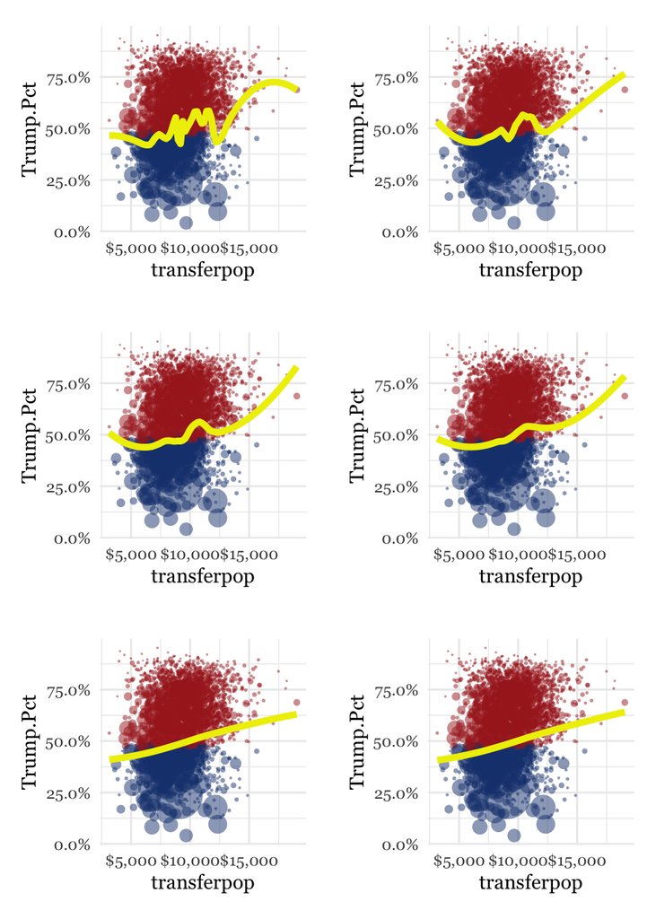

```r
    i <- 1
    z <- list(c)
    while(i < 7) {
        spanv <- i/5
        z[[i]] <- generateLoess(dataset=dataset, x='transferpop', y='Trump.Pct', span=spanv)
        i <- i + 1
    }

  grid.arrange(grobs = z, ncol=2)
```

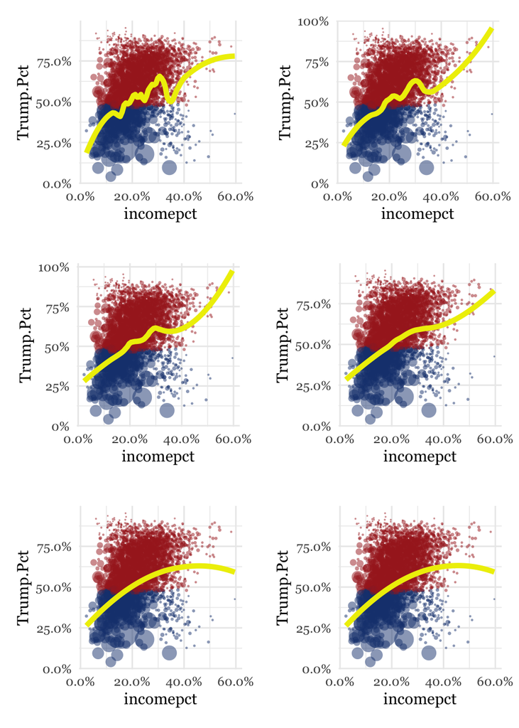

```r
    i <- 1
    z <- list(c)
    while(i < 7) {
        spanv <- i/5
        z[[i]] <- generateLoess(dataset=dataset, x='incomepct', y='Trump.Pct', span=spanv)
        i <- i + 1
    }

  grid.arrange(grobs = z, ncol=2)
```

It’s a similar to problem of choosing bins for histograms. Choosing more bins may reveal patterns. But are they real? Often we’re just seeing sampling noise.

A better way to fit a line than eyeballing a local regression is with [penalized basis spline](https://pdfs.semanticscholar.org/7aaf/d8cf1338c756ea9b0411bb59039773b0fecf.pdf) fit in an additive model. The `gam` function in R provides the functionality we need. We arrive at the chart below. The penalized spline adds and removes knots in such a way that as more knots are added, we penalize the model to prevent overfitting. We arrive at a compromise number of knots with a technique similar to feature selection for ridge regression.

From the Elements of Statistical Learning, Ch. 6, we can get a technical description of how the basis spline works:

> This is done by using only those observations close to the target point x0 to fit the simple model, and in such a way that the resulting estimated function ˆf(X) is smooth in IRp. This localization is achieved via a weighting function or kernel Kλ(x0, xi), which assigns a weight to xi based on its distance from x0.

```r
  gam1 = gam(Trump.Pct ~ s(incomepct), data = dataset, w=pop)
  #we could also use mcgv syntax with brms
  # brms(Trump.Pct ~ s(incomepct), data = dataset, weights=pop)

  pred = predict(gam1, type = "response", se.fit = TRUE)
  new <- data.frame(y = pred, x=dataset$incomepct)

  new$down = new$y.fit - (1.96 * new$y.se.fit)
  new$up = new$y.fit + (1.96 * new$y.se.fit)
```

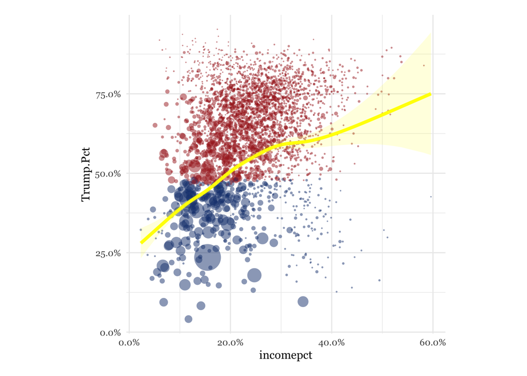

```r
   c <- ggplot() +
    geom_point(data=dataset, aes(x=incomepct, y=Trump.Pct, color=winner, size=pop), alpha= 0.5, stroke=0, show.legend = FALSE) +
    scale_color_manual(values = c("Clinton" = "#1D427E", "Trump" = "#A82723")) +
    geom_line(aes(x,y.fit), data=new, show.legend = FALSE, color='yellow', size=1.5) +
    geom_ribbon(aes(x=x,ymin=down, ymax=up), data=new, show.legend = FALSE, color='yellow', fill='yellow', size=0, alpha=0.15) +
    scale_x_continuous(labels = percent) +
    scale_y_continuous(labels = percent) +
    scale_size(range = c(0.5,12)) + theme_minimal(base_family="Georgia") + theme(aspect.ratio=1) +
    theme(plot.margin = unit(c(0.5,0,0.5,0), "cm"))

  c
```

If we absolutely want to use loess, one good way to do it is to cross-validate the fit of the loess. In other words, fit the line to a subset of the data then test and re-train it on data thas has been held out. Repeat the process until a line is found that minimizes a cost function.

```r
  loessCV <- loess.as(dataset$incomepct, dataset$Trump.Pct, degree = 2, criterion = 'gcv', weight=dataset$pop)

  loesspred <- predict(loessCV)
  newLoess <- data.frame(y = loesspred, x=dataset$incomepct)
```

We can use our cross-validated loess to generate new predictions. We arrive at a line that’s similar to the GAM, with slightly more wiggliness.

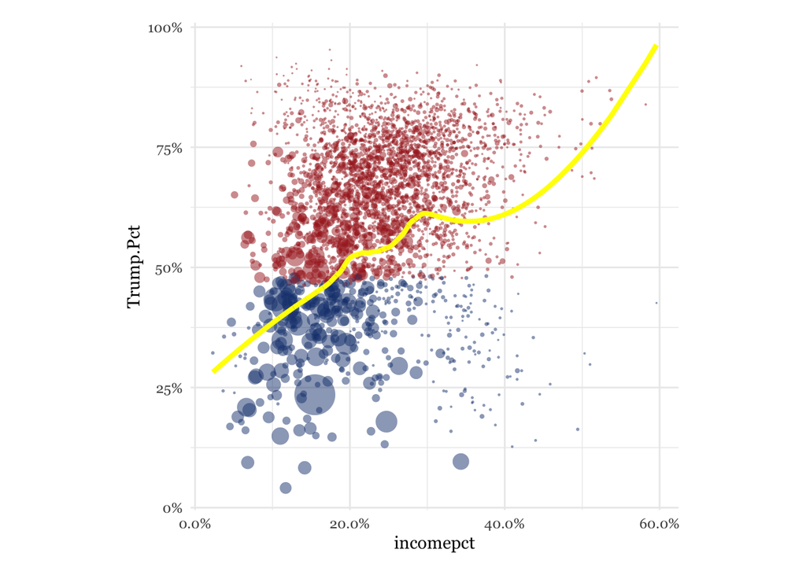

```r
   ggplot() +
    geom_point(data=dataset, aes(x=incomepct, y=Trump.Pct, color=winner, size=pop), alpha= 0.5, stroke=0, show.legend = FALSE) +
    scale_color_manual(values = c("Clinton" = "#1D427E", "Trump" = "#A82723")) +
    geom_line(aes(x,y), data=newLoess, show.legend = FALSE, color='yellow', size=1.5) +
    scale_y_continuous(labels = percent) +
    scale_x_continuous(labels = percent) +
    scale_size_continuous(range = c(0.5,12)) + theme_minimal(base_family="Georgia") + theme(aspect.ratio=1) +
    theme(plot.margin = unit(c(0.5,0,0.5,0), "cm"))
```